# 2023-09-03-risk-OSCAL slides

[figure not shown]

1. Intro to the topic
   - OpenStreetMap
   - Open-Mobility
   - Disaster Risk Management
2. Step-by-step
   - find historical data on fires/floods
   - get basic analysis based on OpenRouteService for accessibility
3. Explore a report
   - fire monitoring from European Space Agency (ESA)

# Introduction

*OpenStreetMap, Open-Mobility, Disaster Risk Management*

[figure not shown]

## Why data

*the value of digital infrastructure*

**CHANGE**: It takes time to setup a sustainable process of improvement, as people have resistance and different views. Having a consistent baseline helps having significant improvements that do not fade away.

**INSTITUTIONALISATION**: The information should not be kept by people that happen to be in that position, as those people might leave or change position. Knowledge transfer is easiest through tools and data.

**PROOF**: Proving a point and the significance of a counter-intuitive argument to a complex problem requires effort. Data and tools make that happen.

**HISTORICAL COMPARISON**: When seeing the evolution in the city, one can understand patterns and decide for significant actions and policies.

**GEOGRAPHICAL COMPARISON**: Comparing with other cities in the same scale or similar geography provides some baseline to compare with, and what to improve first.

## State of the Map using OSM data

*landuse and buildings*

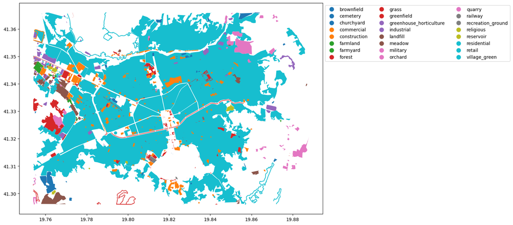

```python
from pyrosm import OSM, get_data
osm = OSM(filepath="data/tirana.pbf")
osm.get_landuse().plot(column="landuse", **std_kwargs)
```

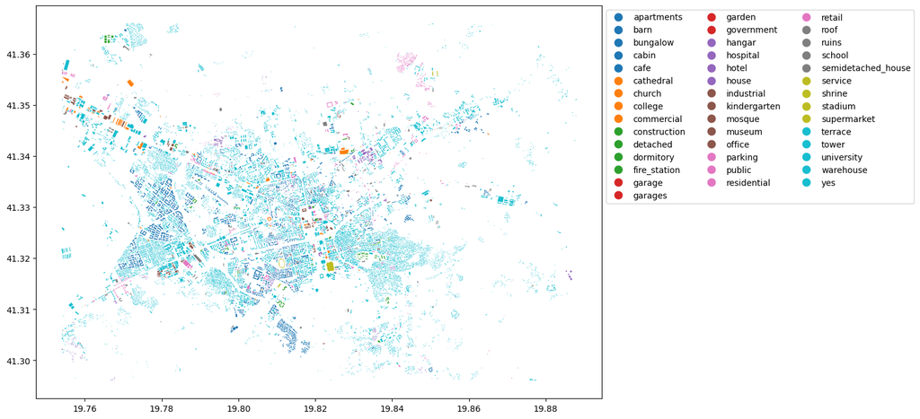

```python
buildings = osm.get_buildings()
ax = buildings.plot(column="building", **std_kwargs)
```

## State of transport network

*streets, routes and stops*

[output not shown]

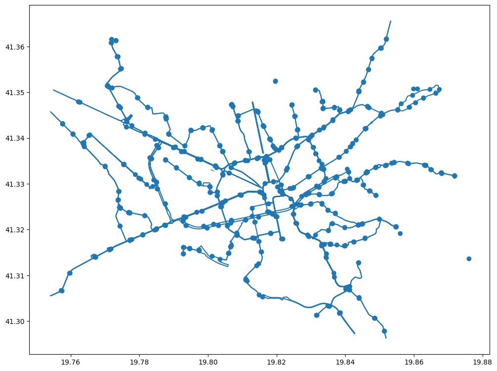

```python
transit.plot(**std_kwargs)
```

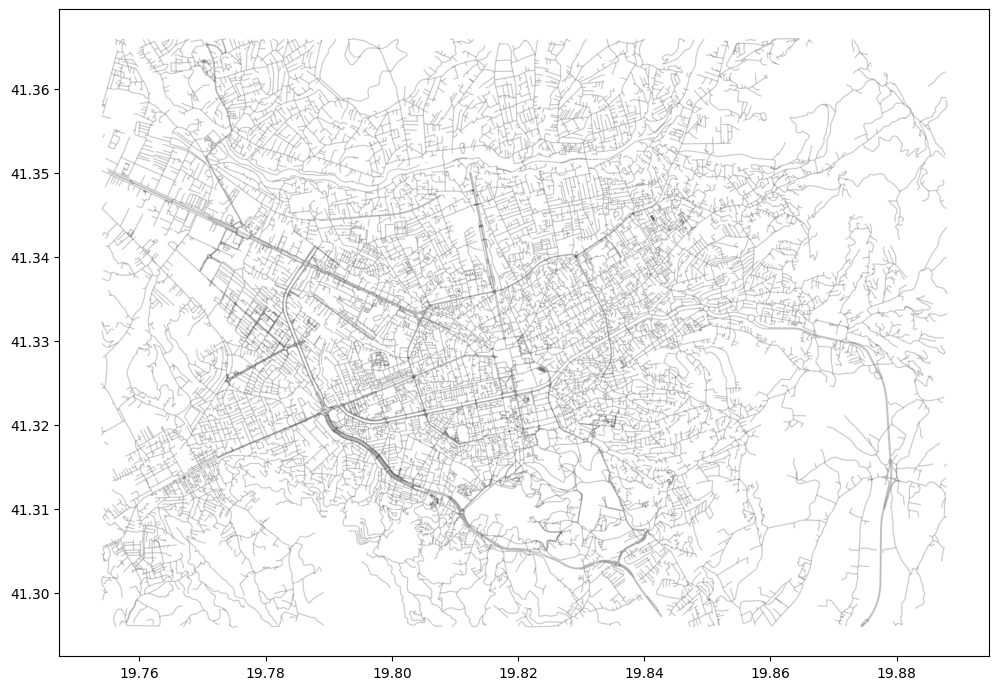

```python
# Apply the same bounding box filter and retrieve walking network
walk = osm.get_network("walking")
walk.plot(color="k", lw=0.9,  alpha=0.2, **std_kwargs)
```

## State of network

*roads and neighborhoods*

[output not shown]

```python
cities_network_stats_df
```

|  | n | m | k_avg | edge_length_total | edge_length_avg | streets_per_node_avg | intersection_count | street_length_total | street_segment_count | street_length_avg | ... | 2way_int_count | 3way_int_count | 4way_int_count | 5way_int_count | 0way_int_prop | 1way_int_prop | 2way_int_prop | 3way_int_prop | 4way_int_prop | 5way_int_prop |
| --- | --- | --- | --- | --- | --- | --- | --- | --- | --- | --- | --- | --- | --- | --- | --- | --- | --- | --- | --- | --- | --- |
| Tirana, Albania | 6657 | 14277 | 4.289320 | 1051280.430 | 73.634547 | 2.510590 | 4829 | 616092.094 | 8269 | 74.506239 | ... | 70 | 4298 | 454 | 7.0 | 0.0 | 0.274598 | 0.010515 | 0.645636 | 0.068199 | 0.001052 |
| Durres, Albania | 3523 | 8286 | 4.703946 | 804217.552 | 97.057392 | 2.543287 | 2585 | 436423.011 | 4454 | 97.984511 | ... | 11 | 2298 | 274 | 2.0 | 0.0 | 0.266250 | 0.003122 | 0.652285 | 0.077775 | 0.000568 |
| Elbasan, Albania | 1654 | 4062 | 4.911729 | 371970.123 | 91.573147 | 2.602177 | 1241 | 191961.137 | 2131 | 90.080308 | ... | 1 | 1073 | 165 | 2.0 | 0.0 | 0.249698 | 0.000605 | 0.648730 | 0.099758 | 0.001209 |
| Shkoder, Albania | 2031 | 4405 | 4.337765 | 335608.415 | 76.188062 | 2.358936 | 1349 | 181444.820 | 2391 | 75.886583 | ... | 5 | 1277 | 67 | NaN | 0.0 | 0.335795 | 0.002462 | 0.628754 | 0.032989 | NaN |

4 rows × 28 columns

[figure not shown]

## Open-Mobility Ecosystem

[figure not shown]

## Route finding

*how to get from one place to next?*  
*use OSMNX https://osmnx.readthedocs.io/en/stable/*

[figure not shown]

## Analyzing trips with OSS

*Analyzing gps data for people, bikes, buses, cars, birds, football players*  
*using movingpandas https://movingpandas.org/*

| People moving | Birds moving | Football |
| --- | --- | --- |

## How do OSS stand for Risk Management

*Example tools that can help with DRM*

[figure not shown]

# Step-by-step

*institutions, data, ORS*

## Institutions on Risk

*what do the institutions think about Risk?*  
*Do we have a plan?*

| [Documentation](https://www.asig.gov.al/images/DokumentaPDF/Standardi_per_temenZonatmeRreziqeNatyrore.pdf) | [Strategy](https://www.undp.org/albania/press-releases/albania-strengthens-resilience-adoption-new-national-disaster-risk-reduction-strategy-and-action-plan) |
| --- | --- |

## Firemaps of Albania

*Can we follow up with data?*

| [2017 Fire Map](https://effis-gwis-cms.s3.eu-west-1.amazonaws.com/effis/reports-and-publications/ercc-daily-map/20170810_Albania_ForestFires.png) | [ASIG](https://www.undp.org/albania/press-releases/albania-strengthens-resilience-adoption-new-national-disaster-risk-reduction-strategy-and-action-plan) |
| --- | --- |

## Continuous Data?

*Can we follow up with data?*  
*Information can be found at the [EFFIS](https://effis.jrc.ec.europa.eu/apps/effis_current_situation/) website*

| Fire History | Fire and Forests |
| --- | --- |

# What can open-source tools provide?

*Where to get started?*

## Disaster Risk Management

*DRM made easy through OSS*  
*e.g. use OpenRouteService https://openrouteservice.org/*

| Logistics | Accessibility map | Healthcare map |
| --- | --- | --- |

## Mapping supplies

*How to distribute help when you do not have the resources?*

[figure not shown]

## Skipping routes

*How to pass from a city with broken streets?*

[figure not shown]

## Reachability of Hospitals

*How do disasters deal with Accessibility?*

[figure not shown]

## OSCAL23

*On Friday we had a community sprint!*  
*Thank you Danijel for the lovely map!*

| OSM Sprint | Berat, Fire Risk |
| --- | --- |

# Actual report

*An example of what a protocol/report would look like ...*

- https://effis.jrc.ec.europa.eu/about-effis/technical-background/wildfire-risk-assesment
- https://rapidmapping.emergency.copernicus.eu/EMSR675/reporting

*Other notes*

- https://wiki.openstreetmap.org/wiki/AlbanianFloodingCrisisCamp
- https://www.openstreetmap.us/news/2021/06/map-for-emergency
- https://effis.jrc.ec.europa.eu/apps/firenews.viewer/
- https://www.asig.gov.al/images/DokumentaPDF/Standardi_per_temenZonatmeRreziqeNatyrore.pdf